# Problem Set 1

Jacob Farmer

2026-08-31

Let’s explore some basic things we can do in R. For these assignments, there will be several ‘code chunks’, like the one below here. In some of these, I have already added code to perform operations that I want you to see.In others, I will instruct you on what code I want you to type in the code chunk The only place you need to add anything is in the code chunks where instructed.

At any point you can check your work by hitting ‘Knit’ in the menu bar above. Doing this will create at html document of the entire problem set. When you are finished with the assignment, this html document is what you will turn in on Canvas.

First, we can use R as a big calculator. Click the green arrow in the code chunk below to run the code.

```r
5*7
```

```
## [1] 35
```

When you click the green ‘run’ arrow, R executes the code in the window and displays the output.

We can also store numbers and other things as objects, which we can later use

Let’s explore this with some basic probability

I want to know the odds of drawing a card with a spade from a 52 card deck. There are thirteen spades (ace-10, jack, queen, king) and 52 cards total. The following code chunk stores both of these numbers and calculates prob_spade, which is the quotient of the two, giving us the probability of drawing a spade.

```r
num_spades <- 13
num_cards_total <- 52
prob_spade <- num_spades/num_cards_total
prob_spade
```

```
## [1] 0.25
```

The last line tells R to display the value of prob_spade.

Below, write some code to store the probability of drawing an ace and store it as prob_ace. Have R display the probability.

```r
num_ace <- 4
prob_ace <- num_ace/num_cards_total
prob_ace
```

```
## [1] 0.07692308
```

Next, I want to know the probability of drawing two aces in a row. This is the probability of drawing an ace from a full deck, which we just calculated, multiplied by the probability of drawing an ace, conditional on having already drawn an ace. This second part is the piece we need to calculate. Fill in the missing pieces of the code chunk so that it will return the probability of drawing a second ace, conditional on having already drawn an ace.

First, create an object called num_aces_left, which is the number of aces that remain in the deck after drawing an ace from a full 52 card deck. Then, create an object called num_cards_left, which is the number of cards that remain. Finally, to get the odds of drawing an ace, conditional on having already drawn an ace, create an object called prob_ace_again which is the quotient of num_aces_left and num_cards_left.

```r
#how many aces are left in the deck?
num_aces_left <- num_ace -1

#how many total cards are left in the deck?
num_cards_left <- 48 + num_aces_left

#calculate the probability of drawing an ace after already drawing an ace
prob_ace_again <- num_aces_left/num_cards_left
prob_ace_again
```

```
## [1] 0.05882353
```

Finally, the probability of drawing back-to-back aces is the product of prob_ace and prob_ace_again. Write some code that calculates this and save it as prob_pocket_aces

```r
prob_pocket_aces <- prob_ace * prob_ace_again
prob_pocket_aces
```

```
## [1] 0.004524887
```

If you play poker, this is the odds of being dealt pocket aces.

Because the probability of drawing an ace changes after your first draw, draws from a deck of cards are not **Independent**. On the other hand, coin flips are independent. If you gets heads once, it does not change your odds of getting heads again. This makes calculating the odds of flipping heads three times in a row easy

```r
prob_heads <- .5
prob_three_heads <- prob_heads^3
prob_three_heads
```

```
## [1] 0.125
```

Let’s write some code to calculate the **Expected Value** of a dice roll. The expected value takes all of the possible outcomes (1-6) and multiplies each by the probability of that outcome (1/6), and then adds all of these up.

To do this, we will introduce a few new terms. First, a **vector** is simply a list of numbers. The formal linear algebra definition is more complicated, but for our purposes this definition will work. You can think of a vector as a single row of data, or a list of regression coefficients. Here, we want a vector of each possible value a dice roll can take, so (1,2,3,4,5,6).

Next, a **scalar** is a single number, or a constant. The odds of getting each value on the die is 1/6, so we can use the scalar 1/6 to calculate the expected value:

```r
#this will create a vector which counts from 1 to 6
possible_rolls <- (1:6)
possible_rolls
```

```
## [1] 1 2 3 4 5 6
```

```r
#here is the probability of each outcome
odds_for_each <- 1/6
#now we multiply our vector of roll outcomes times the probability of getting each and take the sum
expected_value_dice_roll <- sum(possible_rolls*odds_for_each)
expected_value_dice_roll
```

```
## [1] 3.5
```

```r
#notice that we can multiple a vector times a scalar and it will multiply each
#piece of the vector by the scalar.
#this means we can use the sum() function like the summation operator.
```

Notice that we can multiply a vector times a scalar and it will multiply each piece of the vector by the scalar. this means we can use the sum() function like the summation operator.

Using the last code chunk as a template, write some code that sums every integer from 23 to 44 and displays the value.

```r
possible_values <- (23:44)
possible_values
```

```
##  [1] 23 24 25 26 27 28 29 30 31 32 33 34 35 36 37 38 39 40 41 42 43 44
```

```r
totaling_possible_values <- sum(possible_values)
totaling_possible_values
```

```
## [1] 737
```

Write some code that shows that squaring a sum is not the same as summing squares Hint: to see if two things are equal, you can use ==

2 == 4

Running the line above returns ‘FALSE’ while running this:

3 == 3

Returns ‘TRUE’. write your code to accomplish the above here:

```r
x <- (1:5)
#first, use the sum() function to sum the rows of x, then square that value (call this sumx_sq)
sumx_sq <- (sum(x))^2
sumx_sq
```

```
## [1] 225
```

```r
#next, multiply x by itself, then sum the rows of the new vector (call this sum_xsq)
xsq <- x*x
sum_xsq <- sum(xsq)
sum_xsq
```

```
## [1] 55
```

```r
#test whether the two objects are equal
sumx_sq == sum_xsq
```

```
## [1] FALSE
```

**VARIANCE** One thing we are going to be interested in is learning how a variable deviates from it’s mean. for example, if x is a vector going from 1 to 10, as above:

```r
x <- (1:10)
mean(x)
```

```
## [1] 5.5
```

The mean is 5.5

Create a vector called ‘differences’ that calculates the difference between each value of x and the mean. Have R display the vector

```r
differences <- x-mean(x)
differences
```

```
##  [1] -4.5 -3.5 -2.5 -1.5 -0.5  0.5  1.5  2.5  3.5  4.5
```

We are also interested in the sum of squared differences, as this tells us about how much the variable varies. Created a vector that squares the values in ‘differences’ and display it

```r
differences_sq <- differences^2
differences_sq
```

```
##  [1] 20.25 12.25  6.25  2.25  0.25  0.25  2.25  6.25 12.25 20.25
```

```r
sum_sq_differences <- sum(differences_sq)
sum_sq_differences
```

```
## [1] 82.5
```

The sum of these squared differences divided by N-1 is called the variance. write a line of code that calculates this variance.

(hint: N is the number of observations in the vector x, you can calculate it by using ‘length(x)’)

```r
variance <- sum_sq_differences/((length(x)-1))
variance
```

```
## [1] 9.166667
```

Fortunately R has a function to calculate the variance for us:

```r
var(x)
```

```
## [1] 9.166667
```

Write a line of code to test whether the variance you calculated is equal to the variance R calculates using var(x)

```r
var(x) == variance
```

```
## [1] TRUE
```

**COVARIANCE** In economics, we are often interested in whether two variables move in the same direction or not. let’s start with a simple example.

```r
x <- (1:10)
y <- (10:1)
```

Here when x goes up, y goes down. Let’s calculate their covariance the first step is to calculate the difference between each value of x and y and their mean

```r
x_dif <- x - mean(x)
y_dif <- y - mean(y)
```

Then we multiply these two vectors by one another. If the variables move together, these products should be big and positive. If they move in opposite directions, they will be big and negative.

```r
xy_dif <- x_dif * y_dif
xy_dif
```

```
##  [1] -20.25 -12.25  -6.25  -2.25  -0.25  -0.25  -2.25  -6.25 -12.25 -20.25
```

Now we take the sum of this vector and divide by N-1. This code chunk will demonstrate that our method for calculating covariance gives us the same result as when R uses the covariance function.

```r
xy_cov <- sum(xy_dif)/(length(xy_dif)-1)
xy_cov
```

```
## [1] -9.166667
```

```r
xy_cov == cov(x,y)
```

```
## [1] TRUE
```

Notice the covariance is -9.16 which means they move in opposite direction

Let’s look at a scatter plot

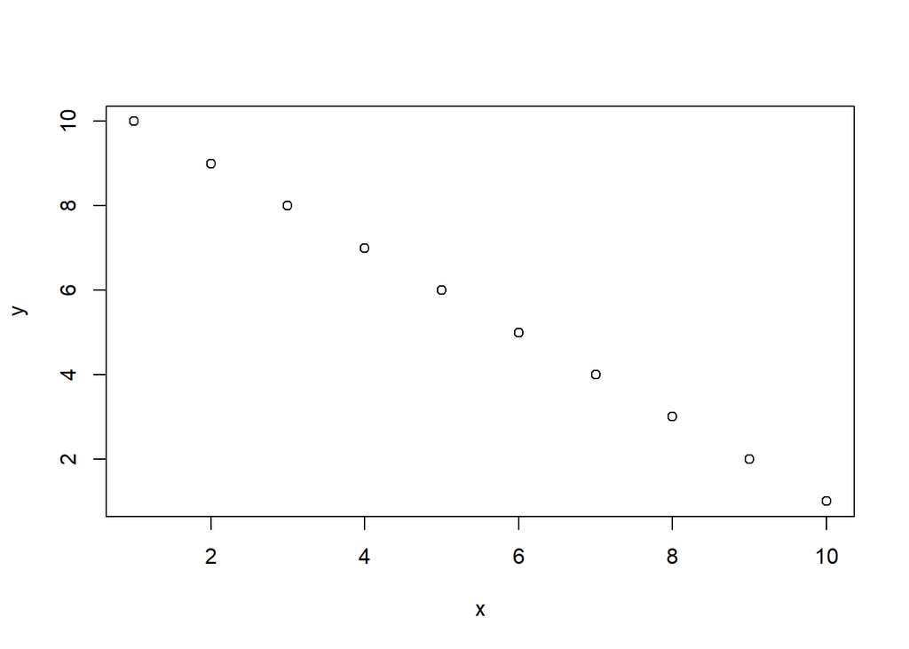

```r
plot(x,y)
```

These clearly move in opposite directions. When x goes up, y goes down and vice versa

Let’s take the covariance of two variables that are independent. Run this code chunk:

```r
x <- rnorm(10)
y <- rnorm(10)
cov(x,y)
```

```
## [1] 0.137554
```

You likely got a small number. Run that chunk a few more times. It should bounce back and forth around zero.

Write some code to make a scatter plot of these variables

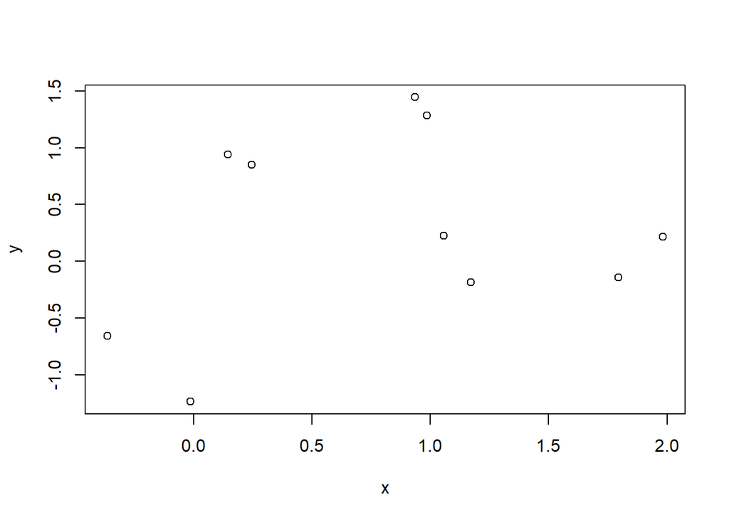

```r
plot(x,y)
```

Repeat the three lines of code from just above with 1,000 draws instead of 10. Run it several times.

```r
x <- rnorm(1000)
y <- rnorm(1000)
cov(x,y)
```

```
## [1] -0.006083228
```

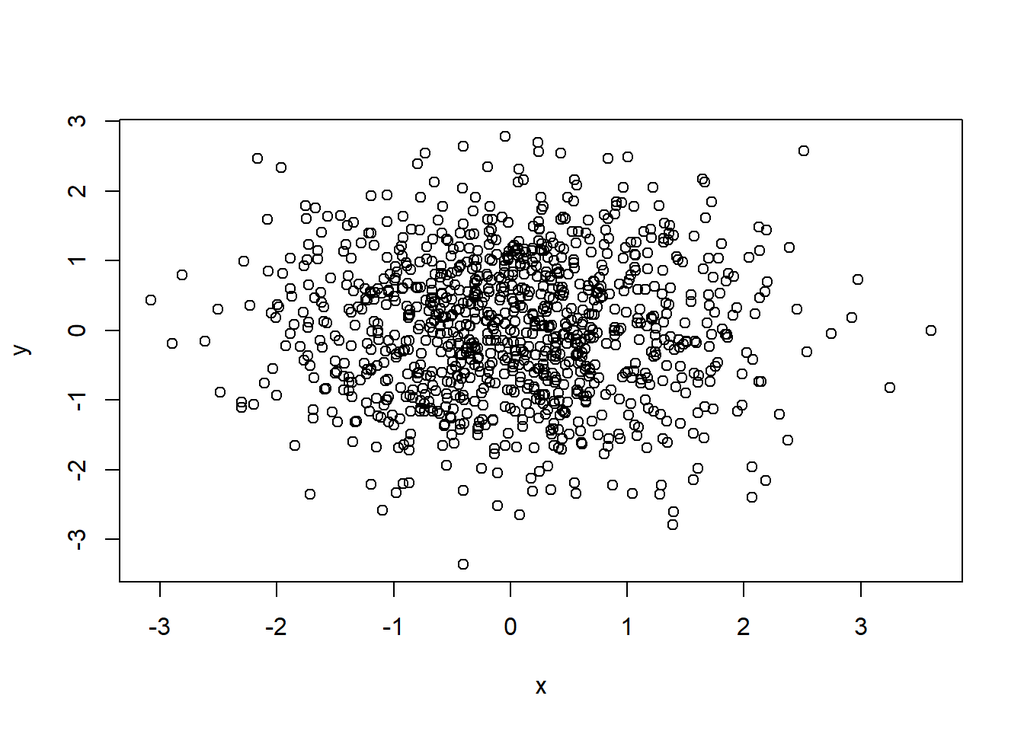

```r
plot(x,y)
```

Notice how the bigger sample sizes leads to covariances more tightly clustered around zero.

Let’s create two variables that are positively related

```r
set.seed(1)
x <- rnorm(10000)
y <- x + rnorm(10000)
```

Write some code to calculate the covariance between x and y and make a scatter plot of the two variables.

```r
cov(x,y)
```

```
## [1] 1.029725
```

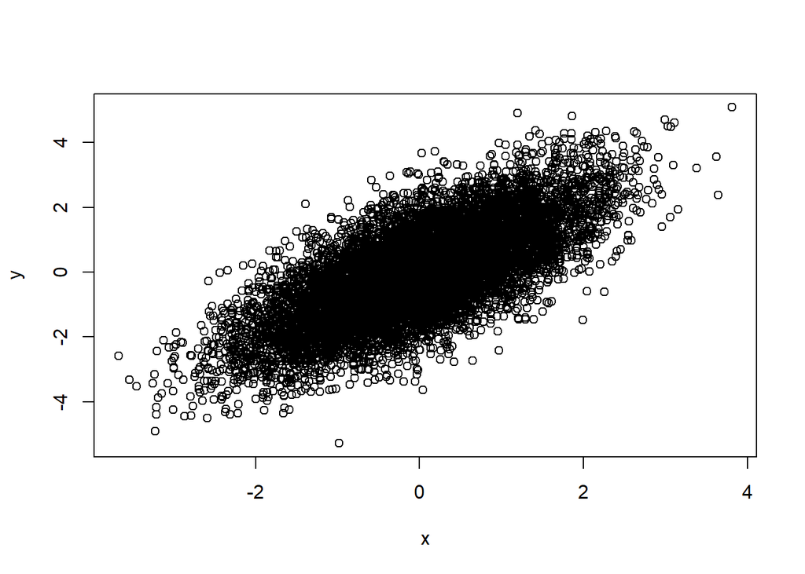

```r
plot(x,y)
```

Does it make sense that the covariance is approximately 1? Why or why not?

**REGRESSION** If we regress y on x, the coefficient on x is equal to the covariance of y and x, divided by the variance of x (we will go into more detail about why this is).

Write some code that manually calculates the coefficient on x. We are still using the x and y we created above.

Store the coefficient as beta_hat and then have R display the value.

```r
beta_hat <- (cov(x,y))/var(x)
beta_hat
```

```
## [1] 1.004742
```

```r
lm <- lm(y~x)
summary(lm)
```

```
##
## Call:
## lm(formula = y ~ x)
##
## Residuals:
##     Min      1Q  Median      3Q     Max
## -4.2940 -0.6793 -0.0144  0.6648  3.7265
##
## Coefficients:
##              Estimate Std. Error t value Pr(>|t|)
## (Intercept) -0.004159   0.009908   -0.42    0.675
## x            1.004742   0.009788  102.65   <2e-16 ***
## ---
## Signif. codes:  0 '***' 0.001 '**' 0.01 '*' 0.05 '.' 0.1 ' ' 1
##
## Residual standard error: 0.9908 on 9998 degrees of freedom
## Multiple R-squared:  0.5131, Adjusted R-squared:  0.5131
## F-statistic: 1.054e+04 on 1 and 9998 DF,  p-value: < 2.2e-16
```

```r
x_coef <- coef(lm)["x"]
```

Finally, test whether your calculated variable is equal to x_coef from this last code chunk

```r
beta_hat == x_coef
```

```
##     x
## FALSE
```